# Johnson-Lindenstrauss Lemma

Levi Lopes de Lima

2025-12-05

#### Explaining the lab

We will present below an illustrative simulation of the **Johnson-Lindenstrauss Lemma**, which turns out to be a cornerstone of high-dimensional probability and computer science, celebrated for its powerful and counter-intuitive result about **dimensionality reduction**. Since no complicated algorithm is required to find the “best” projection implementing the data reduction, as a simple random projection certainly works with very high probability, the lemma turns out to be not just a theoretical curiosity but a practical and efficient tool with many applications in various real-world scenarios such as:

- **Machine Learning**, where it speeds algorithms whose implementation and efficiency rely on evaluating **Euclidean** distances (such as *k-Nearest Neighbors (k-NN)* and *support vector machines*, among others).
- **Data Streaming**, where it helps processing massive datasets not quite fitting into the available memory by still maintaining a low-dimensional “sketch” of the data.
- **Compressed Sensing**, where it plays a key role in recovering sparse signals from a small number of measurements.

All the math needed to understand the analysis may be found in (Lima 2025); updates and corrections of this text may also be found in this repo (check the file “prob-notes-levi-arxiv-ff.pdf”).

#### A glimpse at the theory

Let us recall the precise statement of the Johnson-Lindenstrauss Lemma, which says: if $\mathcal C=\{x_1,\cdots,x_n\}\subset\mathbb R^d$ is a collection of $n$ points then, given $\epsilon, \delta\in(0,1)$, there exist $k= O(\epsilon^{-2}\log (n/\delta))$ and a map $F:\mathbb R^d\to\mathbb R^k$ such that
$$1-\epsilon\leq \frac{\|F(x_i)-F(x_j)\|^2}{\|x_i-x_j\|^2}\leq
1+\epsilon,$$
for all $x_i\neq x_j$ in $\mathcal C$.

Regarding this result, we make the following comments:

- In applications to Data Science (Vershynin 2018),(Blum, Hopcroft, and Kannan 2020), the number $n$ of **samples** is much smaller than the number $d$ of **features**.
- The remarkable aspect of the lemma is that if we allow for a controlled distortion $\epsilon>0$ on the ``approximate projection’’ $F$, $\mathcal C$ has a sort of **intrinsic dimension** $k$ which scales as $\log n$ and happens to be completely insensitive to the ambient dimension $d$, which might even be infinite. This means that there exists a subset $\mathcal I\subset \{1,\cdots,p\}$ of indexes with $\sharp \mathcal I=d-k$ such that $y_j=0$ for all $y\in F(\mathcal C)$ and $j\in\mathcal I$. In other words, up to an overall distortion measured by $\epsilon$, $k=C\epsilon^{-2}\log n$, for some $C>0$, turns out to be the number of relevant (nonzero) features of the elements of $\mathcal C$, hence the importance of the result for data reduction.
- Although the lemma’s statement is deterministic in nature, its standard proof (Lima 2025, chap. 5) employs the **probabilistic method**, which roughly consists of upgrading the assertion we intend to prove (the purely deterministic statement involving the ``approximate projection’’ $F$) to a random event (by turning $F$ into a random matrix) and then checking that the associated random event occurs with **positive** probability.

#### Loading the packages

```r
library(ggplot2)
library(htmltools)
```

#### Starting the simulation

In order to run a simulation for the Johnson-Lindenstrauss Lemma, we construct a function which generates high-dimensional data (in dimension $d$), projects it down to a lower dimension $k$ (by means of a random $k\times d$-matrix whose entries follow independent standard normals), and calculates the preservation of pairwise distances. We will provide the appropriate parameters

- the number of points $n$;
- the original high dimension $d$;
- the error tolerance $\epsilon$ (between 0 and 1);
- a numerical constant $C$ involved in the calculation of $k$;
- the seed integer, for reproducibility,

and the simulation will return

- A printable list containing the simulation results: the chosen initial parameters, the value of $k$ and the distance preservation percentage (in brief, a summary);
- a `ggplot` object from which the actual plot can be extracted

```r
run_jl_simulation <- function(n, d, epsilon = 0.2, C = 15, seed = 42) {
  set.seed(seed)
  k <- ceiling(C * log(n) / epsilon^2)
  if (k >= d) {
    stop(sprintf(
      "Simulation stopped. The required dimension k=%d is not less than the original dimension d=%d. \nTry increasing d or n, or increasing epsilon.",
      k, d
    ))
  }
  X_original <- matrix(rnorm(n * d), nrow = n, ncol = d)
  projection_matrix <- matrix(rnorm(k * d), nrow = k, ncol = d)
  X_projected <- (X_original %*% t(projection_matrix)) * (1 / sqrt(k))
  dist_orig_sq <- as.matrix(dist(X_original)^2)
  dist_proj_sq <- as.matrix(dist(X_projected)^2)
  original_dists_vec <- dist_orig_sq[upper.tri(dist_orig_sq)]
  projected_dists_vec <- dist_proj_sq[upper.tri(dist_proj_sq)]
  ratios <- projected_dists_vec[original_dists_vec > 1e-9] / original_dists_vec[original_dists_vec > 1e-9]
  lower_bound <- 1 - epsilon
  upper_bound <- 1 + epsilon
  preservation_pct <- 100 * sum(ratios >= lower_bound & ratios <= upper_bound) / length(ratios)
  plot_data <- data.frame(ratio = ratios)
  jl_plot <- ggplot(plot_data, aes(x = ratio)) +
    geom_histogram(bins = 50, fill = "steelblue", color = "black", alpha = 0.8) +
    geom_vline(xintercept = c(lower_bound, upper_bound), color = "red", linetype = "dashed", linewidth = 1) +
    labs(
      title = "Distribution of Distance Ratios After Projection",
      subtitle = sprintf("n=%d, d=%d -> k=%d. Preservation: %.2f%%", n, d, k, preservation_pct),
      x = "Ratio of Squared Distances (Projected / Original)", y = "Count"
    ) + theme_minimal()
  return(list(
    params = list(n = n, d = d, epsilon = epsilon, C = C),
    k = k,
    preservation_percentage = preservation_pct,
    plot = jl_plot
  ))
}
# Defines the colors
jl_summary_colors <- c(
  params = "#e6f0ff",
  reduction = "#fffacd",
  verification = "#f0fff0"
)
# This is the summary function
summarize_jl_results <- function(jl_results) {
  create_colored_block <- function(full_text, color) {
    sprintf(
      '<div style="background-color: %s; border: 1px solid #ddd; border-radius: 5px; padding: 10px; margin-bottom: 10px;"><pre style="font-size: 1em; margin: 0;">%s</pre></div>',
      color,
      htmltools::htmlEscape(full_text)
    )
  }
  # This provides the text content for each block
  # Block 1: Parameters
  params_text <- paste(
    "--- Simulation Parameters ---",
    paste("Number of points (n):", jl_results$params$n),
    paste("Original dimension (d):", jl_results$params$d),
    paste("Error tolerance (epsilon):", jl_results$params$epsilon),
    paste("k-specifying constant (C):", jl_results$params$C),
    sep = "\n"
  )
  # Block 2: Reduction
  reduction_text <- paste(
    "--- Dimensionality Reduction ---",
    paste("Required lower dimension (k):", jl_results$k),
    sprintf("Reduction factor: %.2f-fold", jl_results$params$d / jl_results$k),
    sep = "\n"
  )
  # Block 3: Verification
  verification_text <- paste(
    "--- Verification of the JL Lemma ---",
    sprintf("Percentage of pairs preserved: %.2f%%", jl_results$preservation_percentage),
    sep = "\n"
  )
  # Convert each text block into a colored HTML block
  html_block1 <- create_colored_block(params_text, jl_summary_colors["params"])
  html_block2 <- create_colored_block(reduction_text, jl_summary_colors["reduction"])
  html_block3 <- create_colored_block(verification_text, jl_summary_colors["verification"])
  # Combine and print the final html
  final_html <- paste(html_block1, html_block2, html_block3, sep = "\n")
  knitr::asis_output(final_html)
}
```

We may now run the simulation with specified parameters and print the summary with the aimed results.

```r
jl_results <- run_jl_simulation(n = 200, d = 20000)
summarize_jl_results(jl_results)
```

```
--- Simulation Parameters ---
Number of points (n): 200
Original dimension (d): 20000
Error tolerance (epsilon): 0.2
k-specifying constant (C): 15
```

```
--- Dimensionality Reduction ---
Required lower dimension (k): 1987
Reduction factor: 10.07-fold
```

```
--- Verification of the JL Lemma ---
Percentage of pairs preserved: 100.00%
```

Note that we prescribed $(n,d)=(200,20000)$ while keeping the remaining parameter vector $(\epsilon,C)=(0.2,15)$ as in default. In any case, we may now view the pertinent plot in order to visually confirm the $100.00\%$ of distance preservation between the set of projected pair of points.

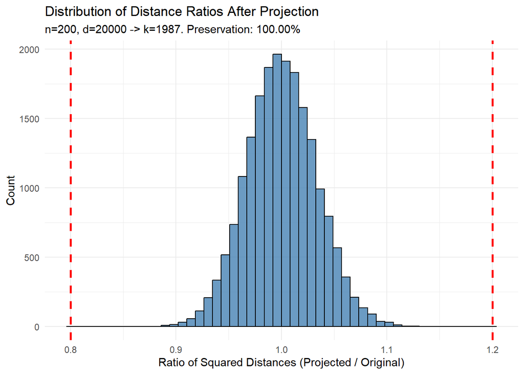

```r
print(jl_results$plot)
```

We thus see that the distribution of distance ratios (after projection) remains entirely within the prescribed interval $[0.8,1.2]$, thus confirming JL.

We may now try other choices for the parameter $\epsilon$, the error tolerance, say by shrinking it a bit…

```r
jl_results <- run_jl_simulation(n = 200, d = 20000, epsilon=0.15)
summarize_jl_results(jl_results)
```

```
--- Simulation Parameters ---
Number of points (n): 200
Original dimension (d): 20000
Error tolerance (epsilon): 0.15
k-specifying constant (C): 15
```

```
--- Dimensionality Reduction ---
Required lower dimension (k): 3533
Reduction factor: 5.66-fold
```

```
--- Verification of the JL Lemma ---
Percentage of pairs preserved: 100.00%
```

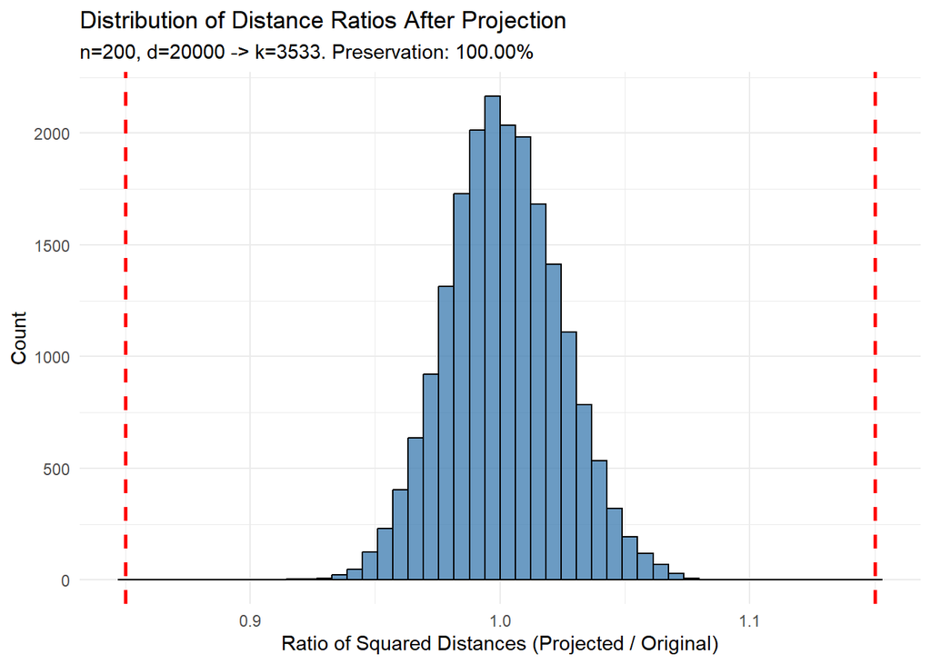

```r
print(jl_results$plot)
```

…which again confirms JL.

We may instead substantially decrease $C$ to see what happens:

```r
jl_results <- run_jl_simulation(n = 200, d = 20000, C=5)
summarize_jl_results(jl_results)
```

```
--- Simulation Parameters ---
Number of points (n): 200
Original dimension (d): 20000
Error tolerance (epsilon): 0.2
k-specifying constant (C): 5
```

```
--- Dimensionality Reduction ---
Required lower dimension (k): 663
Reduction factor: 30.17-fold
```

```
--- Verification of the JL Lemma ---
Percentage of pairs preserved: 99.94%
```

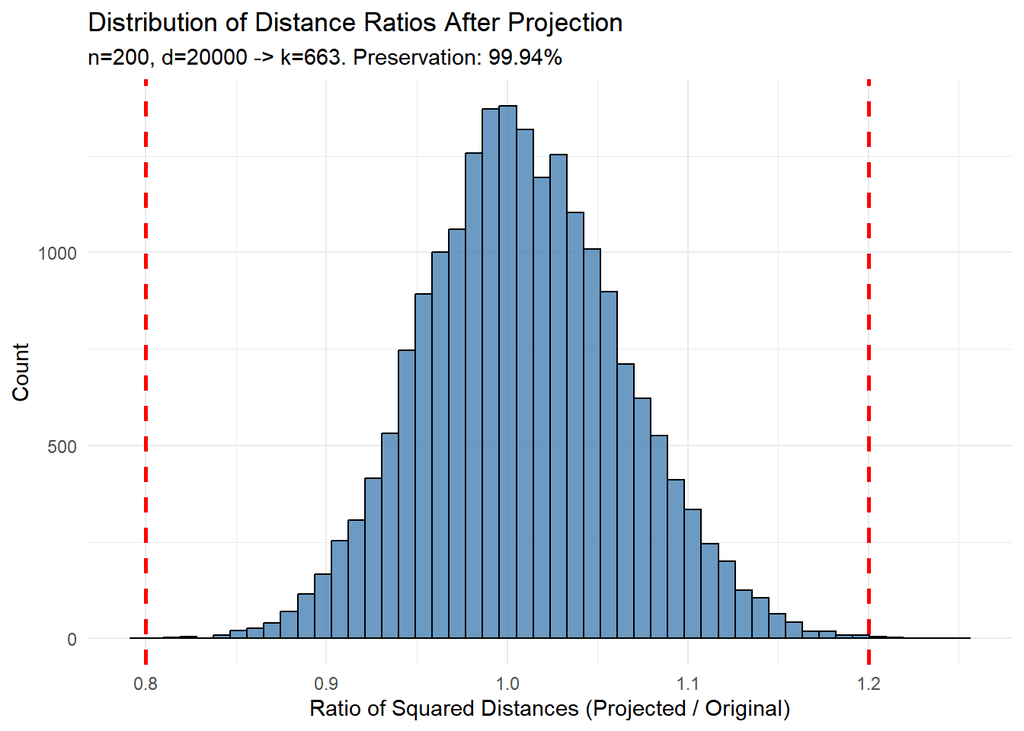

```r
print(jl_results$plot)
```

Needless to say, you may keep playing around with other values for the input parameters but you should be aware that your computational power may easily fail if $d$ is chosen large enough. So go ahead at your own risk…

#### References

Blum, Avrim, John Hopcroft, and Ravindran Kannan. 2020. *Foundations of Data Science*. Cambridge University Press.

Lima, Levi Lopes de. 2025. “Topics in Probability, Parametric Estimation and Stochastic Calculus.” https://arxiv.org/abs/2510.20163.

Vershynin, Roman. 2018. *High-Dimensional Probability: An Introduction with Applications in Data Science*. Vol. 47. Cambridge university press.